# Analiza danych_HR

# 1 Wprowadzenie

**Cel projektu:** Celem niniejszego projektu jest analiza zbioru danych HR pod kątem identyfikacji przyczyn rotacji pracowników. Jest to kluczowe zagadnienie biznesowe, ponieważ koszty związane z rekrutacją i onboardingiem (wraz z utraconą produktywnością) szacuje się na 50–200% rocznego wynagrodzenia odchodzącego pracownika.

**Zakres analizy:** W projekcie zwróciliśmy szczególną uwagę na znalezienie zależności między odejściem pracownika a zmiennymi takimi jak: nadgodziny, wynagrodzenie, wiek czy środowisko pracy. Analiza ma na celu wskazanie obszarów, które wymagają działań prewencyjnych.

**Struktura raportu:** Raport składa się z: wprowadzenia, data cleansing oraz data wrangling, wizualizacji danych, wnioskowania oraz podsumowania i wniosków końcowych.

**Dane**: Zbiór danych zawiera 1470 wierszy oraz 35 kolumn.

## 1.1 Pytania badawcze

- Czy nadgodziny i niskie zadowolenie ze środowiska zwiększają ryzyko odejścia pracownika?
- Czy pracownicy z niższym miesięcznym wynagrodzeniem lub rzadkimi awansami odchodzą częściej?
- Jaka jest charakterystyka (wiek, staż pracy) pracownika, który najczęściej decyduje się na odejście?
- Które działy oraz stanowiska są najbardziej narażone na odejścia pracowników?

## 1.2 Opis danych

Analizowany zbiór danych zawiera informacje dotyczące pracowników firmy.

**Zmienne w zbiorze danych można podzielić na następujące kategorie:**

- **Zmienna Objaśniana:** Attrition: Zmienna kategoryczna wskazująca na to, czy pracownik odszedł z firmy.
- **Zmienne Demograficzne i Osobiste:** Age: Wiek pracownika (Lata) Gender: Płeć pracownika. MaritalStatus: Stan cywilny (Single, Married, Divorced). Education: Poziom wykształcenia (1-5). EducationField: Dziedzina wykształcenia (np. Life Sciences, Medical). DistanceFromHome: Odległość od domu.
- **Zmienne Związane z Pracą oraz Rolą:** Department: Dział, w którym pracuje dana osoba (Sales, R&D, HR). JobRole: Konkretne stanowisko, które zajmuję dana osoba (np. Sales Executive, Laboratory Technician). JobLevel: Poziom stanowiska w strukturze firmy. BusinessTravel: Częstotliwość podróży służbowych (Rarely, Frequently, Non-Travel). OverTime: Czy pracownik pracuje w godzinach ponadwymiarowych (Yes/No).
- **Wynagrodzenie i Benefity:** MonthlyIncome: Miesięczne wynagrodzenie. DailyRate, HourlyRate, MonthlyRate: Stawki płacowe w różnych ujęciach czasowych. PercentSalaryHike: Procentowa podwyżka wynagrodzenia. StockOptionLevel: Poziom opcji na akcje pracownicze.
- **Satysfakcja i Oceny:** EnvironmentSatisfaction: Zadowolenie ze środowiska pracy. JobSatisfaction: Zadowolenie z wykonywanej pracy. WorkLifeBalance: Ocena równowagi między życiem zawodowym a prywatnym. RelationshipSatisfaction: Satysfakcja z relacji ze współpracownikami. PerformanceRating: Ocena wydajności pracownika.
- **Historia Zatrudnienia:** TotalWorkingYears: Całkowity staż pracy (lata). YearsAtCompany: Liczba lat przepracowanych w obecnej firmie. YearsInCurrentRole: Czas na obecnym stanowisku (lata). YearsSinceLastPromotion: Czas, który upłynął od ostatniego awansu (lata). YearsWithCurrManager: Czas pracy z obecnym menedżerem (lata).

# 2 Porządkowanie i czyszczenie danych

## 2.1 Braki danych

*W danych znajduje sie (91.43 %) kompletnych wartości.*

**Kompletność zmiennych:** W tym kroku sprawdziliśmy to, jaka część kolumn w zbiorze jest całkowicie wolna od brakujących informacji. Obliczenia wykazały, że 91.43% zmiennych jest w pełni kompletnych. Oznacza to, że problem braków danych dotyczy jedynie ok. 8.6% kolumn.

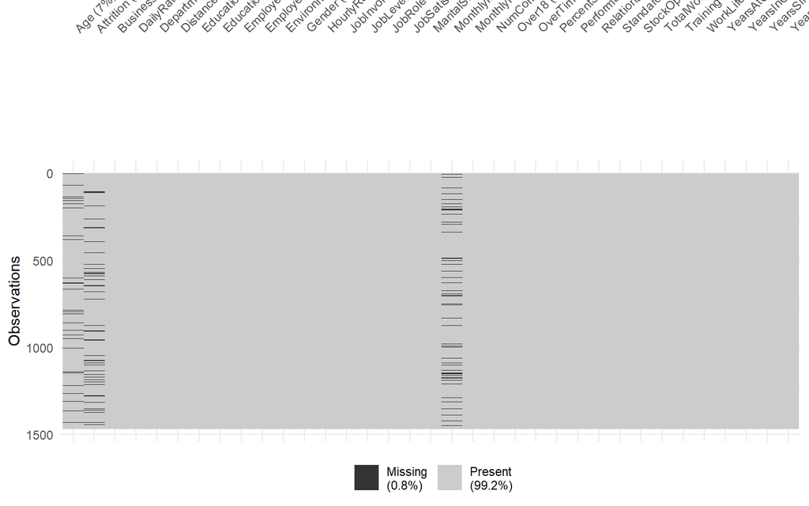

**Ogólny poziom braków:** Sprawdziliśmy globalny odsetek brakujących komórek w całym arkuszu danych. Powyższa wizualizacja wskazuje na to, że jedynie 0.8% wszystkich wartości to braki (kolor czarny), podczas gdy 99.2% danych jest dostępnych (kolor szary). Warto zwrócić uwagę na to, że braki nie występują losowo w całym zbiorze, lecz koncentrują się w konkretnych kolumnach (widoczne, czarne pasy na wykresie). Sugeruje nam to, iż zaobserwowane braki mają charakter systematyczny dla wybranych cech, a nie są wynikiem przypadkowych błędów zapisu dla całego zbioru.

## 2.2 Wizualizacje połączeń w brakach danych

W tej sekcji zastosowaliśmy wizualizację współwystępowania braków, aby zrozumieć ich strukturę w kolumnach Age, Attrition i MonthlyIncome. Naszym celem było sprawdzenie tego, czy wykryte przez nas braku układają się we wzorce.

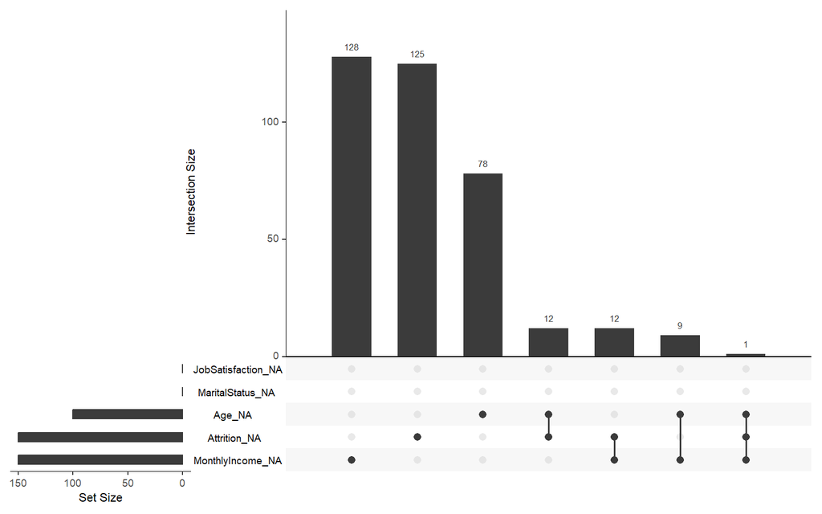

Analiza powyższego wykresu wskazuje na to, iż braki w kolumnach Age, Attrition i MonthlyIncome współwystępują w mniej niż 3% przypadków. Oznacza to brak ukrytych zależności między nimi i sugeruje ich losowy charakter.

Uzupełniając naszą analizę, wygenerowaliśmy wykres macierzowy, którego celem jest zweryfikowanie, czy braki danych grupują się w specyficznych obszarach zbioru czy są równomiernie rozproszone. Pozwoli nam to wykluczyć błędy techniczne powstałe na etapie wprowadzania danych.

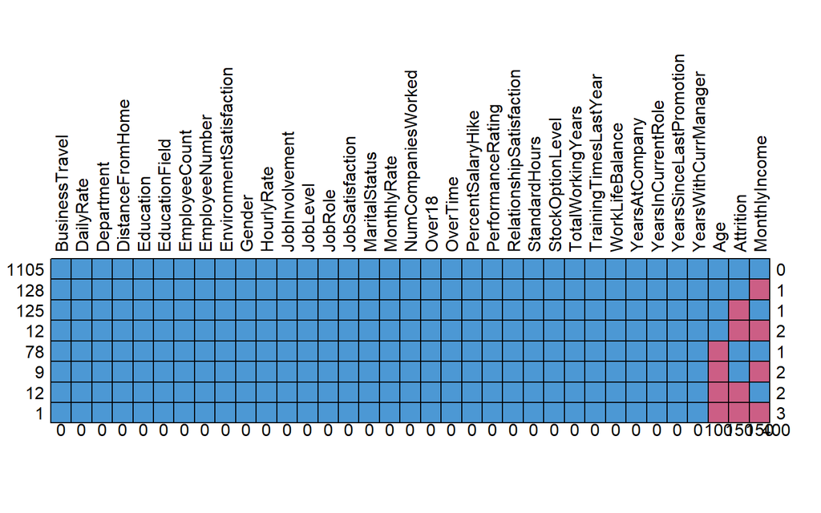

```
##      BusinessTravel DailyRate Department DistanceFromHome Education
## 1105              1         1          1                1         1
## 128               1         1          1                1         1
## 125               1         1          1                1         1
## 12                1         1          1                1         1
## 78                1         1          1                1         1
## 9                 1         1          1                1         1
## 12                1         1          1                1         1
## 1                 1         1          1                1         1
##                   0         0          0                0         0
##      EducationField EmployeeCount EmployeeNumber EnvironmentSatisfaction Gender
## 1105              1             1              1                       1      1
## 128               1             1              1                       1      1
## 125               1             1              1                       1      1
## 12                1             1              1                       1      1
```

[output cut: 65 more lines]

Wykres ukazuje równomierne rozproszenie brakujących wartości w kolumnach Age, Attrition i MonthlyIncome. Brak widocznych, zwartych bloków czy klastrów pustych danych ostatecznie potwierdza, że mamy do czynienia z losowymi brakami, a nie systemowym błędem.

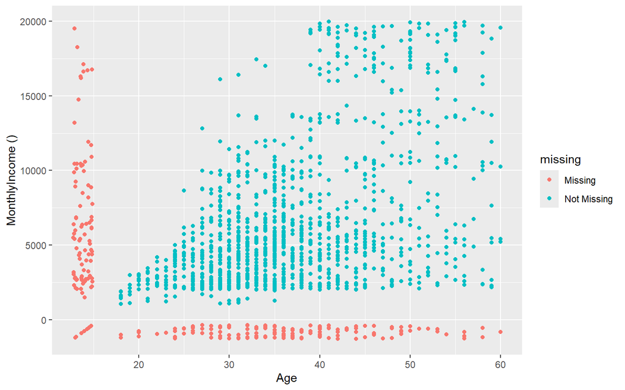

## 2.3 Inputacja metodą Hot-Deck

Zastosowano metodę imputacji Hot-Deck. Jest to technika, w której brakujące wartości są uzupełniane danymi od losowo wybranego “podobnego” rekordu (sąsiada) w zbiorze danych. Metoda ta jest lepsza od uzupełniania średnią, ponieważ pozwala zachować naturalny rozkład zmiennych i ich wariancję.

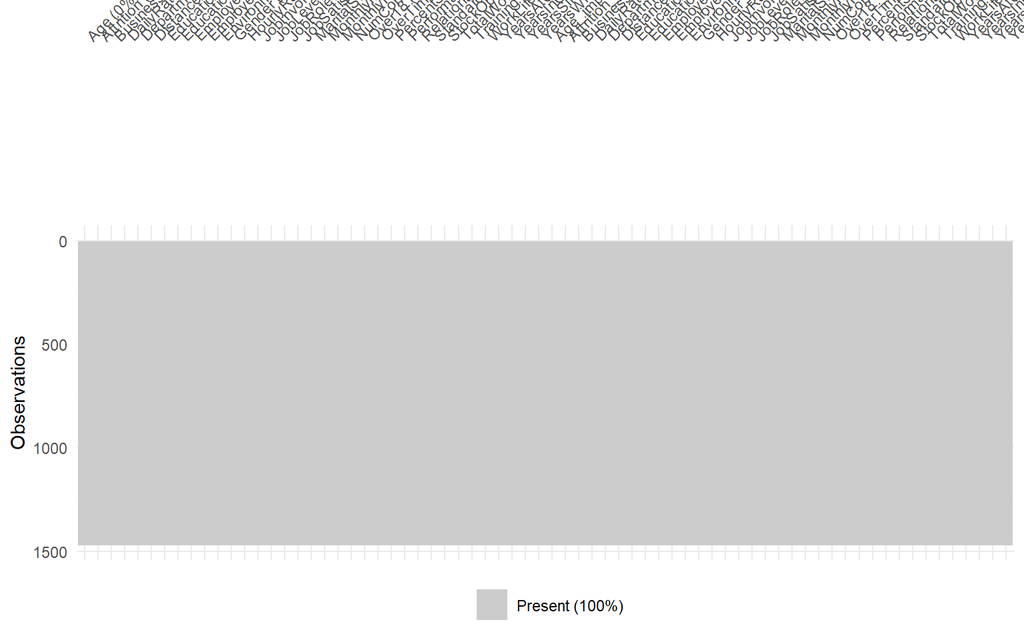

## 2.4 Analiza wartości odstających

### 2.4.1 Sprawdzamy kluczowe zmienne numeryczne pod kątem “outlierów”

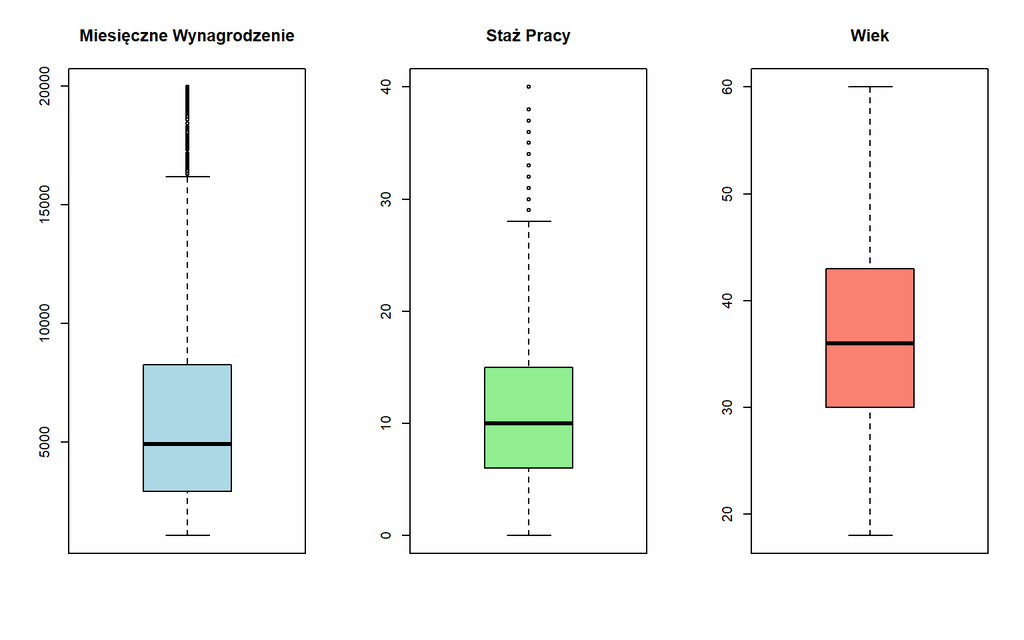

Wykresy pudełkowe wskazują na obecność wartości odstających (kropek) w zmiennych `MonthlyIncome` oraz `TotalWorkingYears`. Jest to zjawisko naturalne w strukturze korporacyjnej – wartości te reprezentują kadrę zarządzającą (Managerów i Dyrektorów) z wieloletnim stażem i wyższymi zarobkami. Nie są to błędy danych, dlatego nie zostaną usunięte z dalszej analizy.

# 3 Walidacja danych

W celu sprawdzenia spójności logicznej danych, poniżej zdefiniowaliśmy reguły, które zostały zestawione z rzeczywistym zbiorem danych za pomocą funkcji confront().

Reguły walidacji danych:

- Staż w firmie (YearsAtCompany) musi być mniejszy lub równy całkowitemu stażowi pracy (TotalWorkingYears).
- Czas na obecnym stanowisku (YearsInCurrentRole) musi być mniejszy lub równy stażowi w firmie (YearsAtCompany).
- Czas pracy z obecnym menedżerem (YearsWithCurrManager) musi być mniejszy lub równy stażowi w firmie (YearsAtCompany).
- Lata od ostatniego awansu (YearsSinceLastPromotion) muszą być mniejsze lub równe stażowi w firmie (YearsAtCompany).

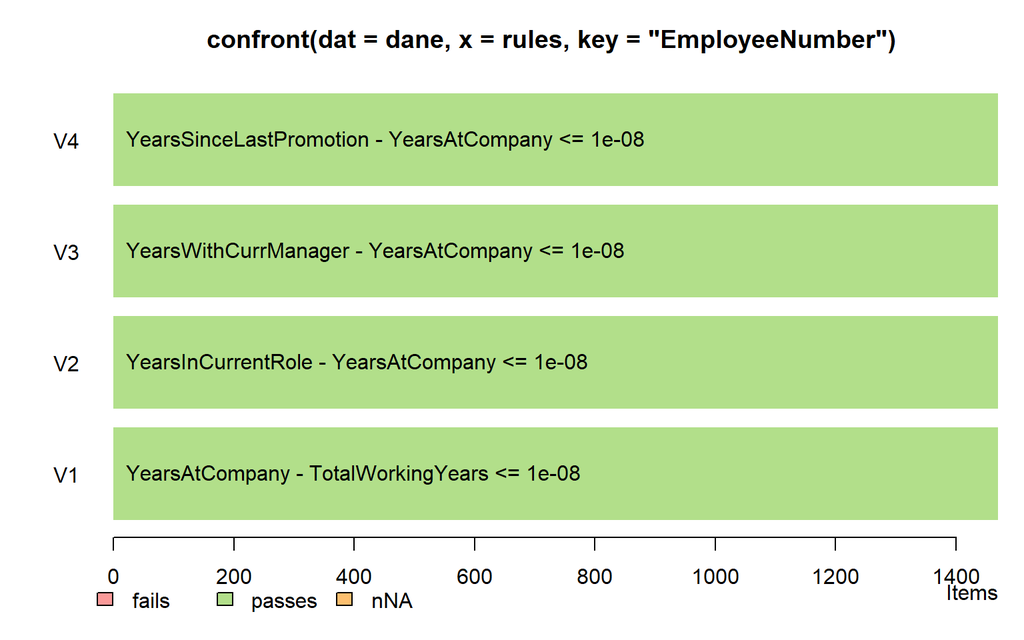

**Całkowity staż pracy** (TotalWorkingYears): Sprawdziliśmy spójność między stażem w obecnej firmie a całkowitym doświadczeniem zawodowym. W tym celu zweryfikowaliśmy, czy YearsAtCompany jest mniejsze lub równe TotalWorkingYears. Nie znaleziono żadnych przypadków naruszenia tej reguły, co oznacza, że u każdego pracownika staż w obecnym przedsiębiorstwie mieści się w ramach jego całkowitej kariery.

**Staż na obecnym stanowisku** (YearsInCurrentRole): Sprawdziliśmy, czy czas spędzony na obecnym stanowisku nie przekracza całkowitego czasu zatrudnienia w firmie. Przetestowaliśmy warunek, w którym YearsInCurrentRole powinno być mniejsze lub równe YearsAtCompany. Wszystkie obserwacje spełniają to kryterium, co potwierdza logiczną poprawność danych dotyczących ścieżki kariery wewnątrz organizacji.

**Czas pracy z obecnym menedżerem** (YearsWithCurrManager): Sprawdziliśmy, czy okres współpracy z obecnym przełożonym jest możliwy w świetle stażu pracownika w firmie. Zbadaliśmy zgodność z regułą YearsWithCurrManager <= YearsAtCompany. Nie odnotowano żadnych błędów, co wskazuje, że relacje podległości są poprawnie osadzone w czasie trwania zatrudnienia.

**Czas od ostatniego awansu** (YearsSinceLastPromotion): Sprawdziliśmy, czy liczba lat, która upłynęła od ostatniego awansu, nie jest większa niż całkowity staż w firmie. Weryfikowano rekordy pod kątem warunku YearsSinceLastPromotion <= YearsAtCompany. Nie znaleziono sprzeczności, co oznacza, że historia awansów jest logicznie spójna z datą rozpoczęcia pracy w firmie.

# 4 Wizualizacja danych

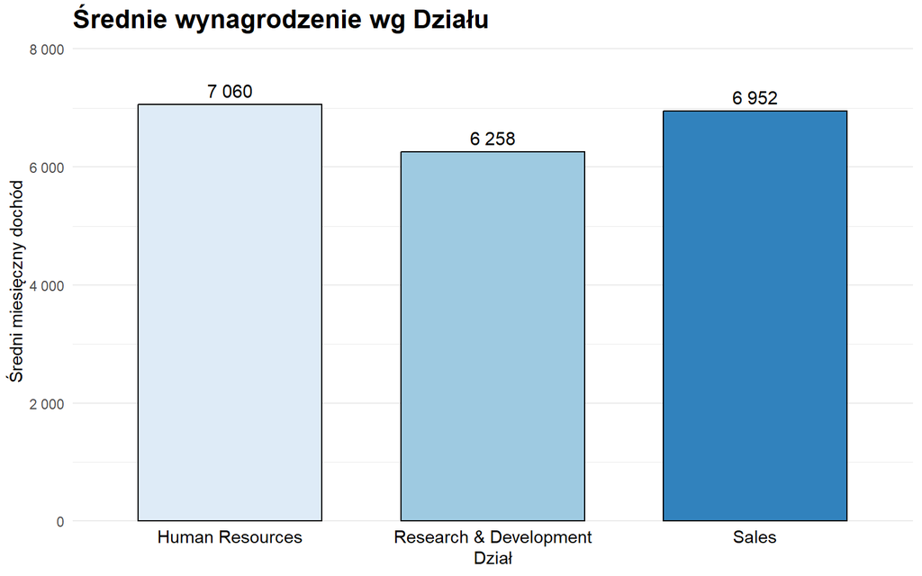

Wykres słupkowy przedstawiony powyżej pokazuje zestawienie średniego miesięcznego wynagrodzenia w podziale na trzy główne działy firmy: Human Resources, Research & Development oraz Sales.

Z danych wynika, że najlepiej opłacaną jednostką organizacyjną jest dział HR z przeciętną pensją na poziomie 7 060. Na drugim miejscu plasuje się Sprzedaż (6 952). Najniższe średnie wynagrodzenie, wynoszące 6 258, zaobserwowano w dziale Badawczo-Rozwojowym (R&D).

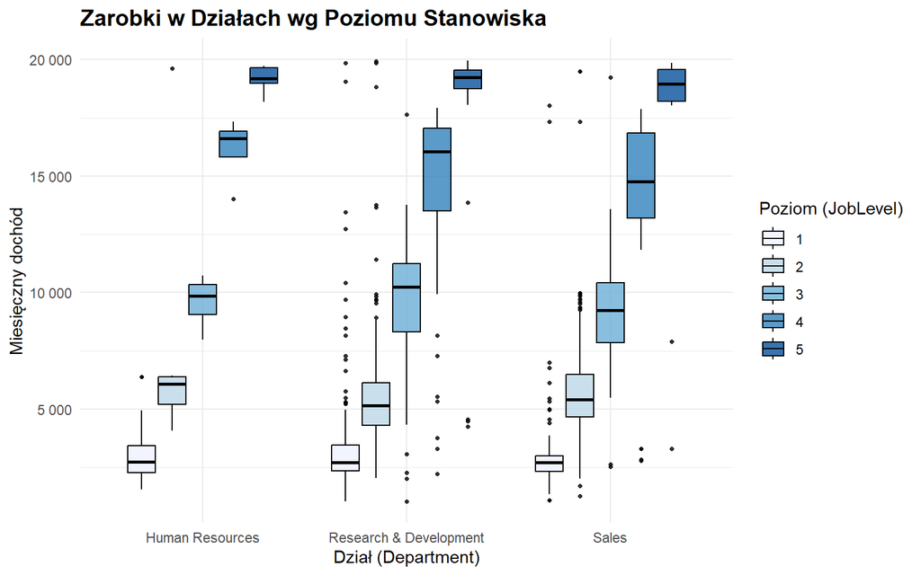

Powyższy wykres przedstawia szczegółową strukturę miesięcznych dochodów w podziale na działy (Department) oraz poziom stanowiska (JobLevel w skali 1–5).

- Zmienność danych (Rozstęp): W działach Research & Development oraz Sales warto zwrócić szczególną uwagę na znaczną rozpiętość wynagrodzeń na średnich oraz wyższych poziomach stanowisk (szczególnie poziomy 3 i 4), co pokazuję wysokość “pudełek”. Wskazuje to na fakt, iż na tych stanowiskach widełki płacowe są bardzo elastyczne.
- Wartości odstające (Outliers): Wykres ujawnia obecność licznych wartości odstających (oznaczonych czarnymi * punktami), szczególnie w dziale Research & Development na niższych poziomach stanowisk. Może to wskazywać na występowanie specyficznych ról specjalistycznych, które są wyceniane wyżej niż standardowe wynagrodzenie dla danego poziomu stanowiska.
- Ciekawy przypadek działu HR: Szczególną uwagę należy zwrócić na dział HR, który wykazuje węższy rozkład danych na większości poziomów w porównaniu do działów Sales oraz R&D. Może to nam sugerować mniejszą liczebności próby w tym dziale lub bardziej ustandaryzowaną siatkę płac.

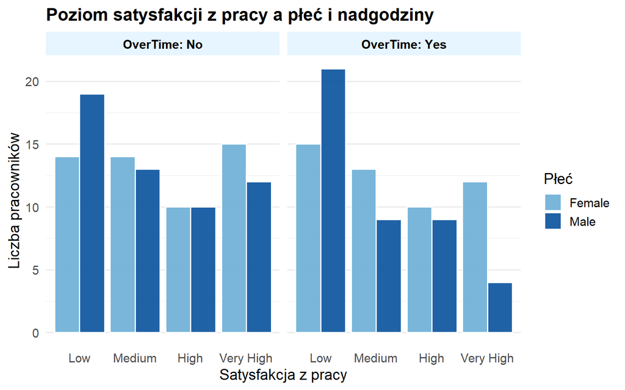

Wykres przedstawiony powyżej pozwala nam zweryfikować hipotezę, czy praca w godzinach nadliczbowych (OverTime) bezpośrednio przekłada się na niezadowolenie pracowników, a także czy płeć ma w tym kontekście znaczenie. Wykres podzieliliśmy na dwie sekcje: osoby nie wykonujące pracy w godzinach nadliczbowowych oraz te, które je wykonują.

**Wnioski:**

- Destrukcyjny wpływ nadgodzin na satysfakcję z pracy: Porównując oba panele, wyraźnie widać, że w grupie osób pracujących w godzinach nadliczbowych (OverTime: Yes) dominuje niska satysfakcja (Low). W przypadku grupy nie wykonujących pracu w godzinach nadliczbowych rozkład ocen jest bardziej zrównoważony.
- Krytyczna sytuacja wśród mężczyzn: Mężczyźni pracujący w godzinach nadliczbowych stanowią najliczniejszą grupę o niskiej satysfakcji (najwyższy słupek na całym wykresie, powyżej 20 osób), a jednocześnie najmniej liczną grupę o satysfakcji bardzo wysokiej (zaledwie kilka osób). Wskazuje to na to, że mężczyźni znacznie gorzej znoszą dodatkowe obciążenie pracą lub bardziej obciążeni pracą w godzinach nadliczbowych.
- Kobiety a nadgodziny: Warto zauważyć, że w grupie kobiet (Female) pracujących w godzinach nadliczbowych, mimo znaczącej ilości niskich ocen, słupek satysfakcji “Very High” jest relatywnie wysoki – wyższy niż u mężczyzn w takiej samej sytuacji. Może to sugerować inne czynniki motywujące lub inną specyfikę stanowisk zajmowanych przez kobiety.
- **Kluczowe wnioski:** Wykres jednoznacznie wskazuje na to, że praca w godzinach nadliczbowych jest istotnie powiązana z niższą satysfkacją z pracy. Szczególną grupą ryzyka, u której należy spodziewać się rotacji, są mężczyźni pracujący w godzinach nadliczbowych. To właśnie w tej grupie firma powinna najpilniej zweryfikować work-life balance, jeśli zależy jej na zapobieganiu odejściom z pracy.

# 5 Statystyki Opisowe

| JobLevel | Min | Max | Średnia | Odchylenie | Mediana | Q1 | Q3 | Skośność | Kurtoza |
| --- | --- | --- | --- | --- | --- | --- | --- | --- | --- |
| 1 | 1051 | 19859 | 3140.04 | 1836.16 | 2718 | 2333.50 | 3443 | 5.45 | 39.34 |
| 2 | 1261 | 19926 | 5602.80 | 2268.47 | 5325 | 4449.25 | 6341 | 3.08 | 15.92 |
| 3 | 1051 | 19246 | 9600.42 | 2420.79 | 9886 | 8011.00 | 10785 | -0.23 | 2.30 |
| 4 | 2232 | 17924 | 14364.56 | 3907.77 | 15982 | 13356.25 | 16885 | -1.77 | 2.48 |
| 5 | 3294 | 19973 | 18078.90 | 3821.39 | 19197 | 18722.00 | 19566 | -3.08 | 8.08 |

Tabela powyżej przedstawia zestawienie kluczowych statystyk opisowych dla zmiennej MonthlyIncome w podziale na JobLevel.

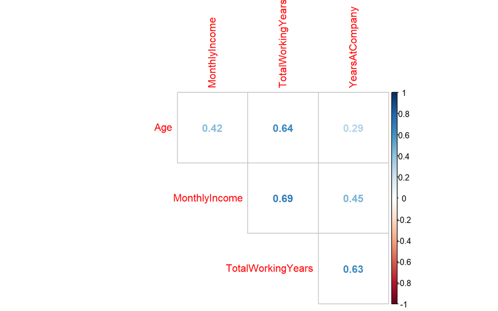

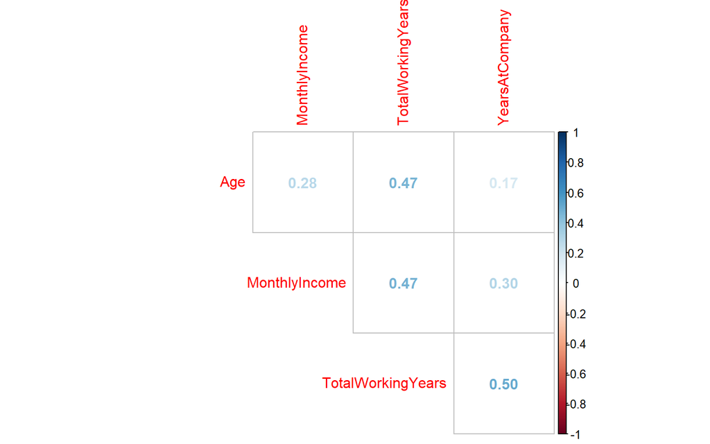

W celu zidentyfikowania powiązań w zbiorze danych, przeprowadziliśmy powyżej analizę korelacji liniowej (Pearsona) oraz rangowej (Kendalla).

Kluczowymi wnioskami wynikającymi z naszej analizy jest m.in. zidentyfikowanie umiarkowanej, dodatniej korelacji pomiędzy dochodem a całkowitym stażem pracy, co jest silniejszym związkiem niż w przypadku wieku pracownika. Warto również zwrócić uwagę na fakt, iż maksymalne wartości współczynników nie przekraczają progu silnej korelacji.

# 6 Wnioskowanie Statystyczne

W tej sekcji zweryfikujemy hipotezy badawcze postawione we wstępie, wykorzystując testy statystyczne.

## 6.1 Testy normalności rozkładu

Przed wyborem odpowiednich testów (parametryczne vs nieparametryczne) sprawdzamy rozkład zmiennej `MonthlyIncome`.

```
## [1] "Wartość p dla testu normalności wynagrodzenia: 3.7e-24"
```

```
## [1] "Odrzucamy hipotezę o normalności rozkładu. Do analizy zależności zastosujemy testy nieparametryczne (np. U Manna-Whitneya)."
```

Uzyskana przez nas wartość p-value nakazuje odrzucenie hipotezy zerowej o normalności rozkładu. Ze względu na niespełnienie założenia parametrycznego, do dalszej analizy zmiennej “MonthlyIncome” zastosujemy testy nieparametryczne.

# 7 Odpowiedź na pytanie badawcze nr 1: Wpływ nadgodzin i środowiska

## 7.1 Czy nadgodziny (OverTime) zwiększają rotację?

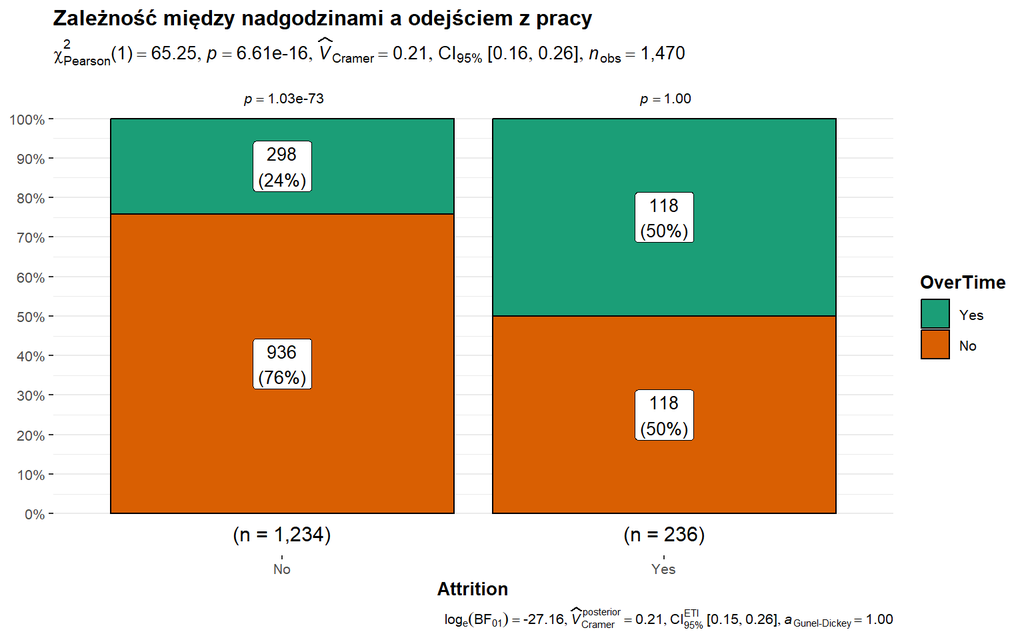

## 7.2 Czy zadowolenie ze środowiska (EnvironmentSatisfaction) ma znaczenie?

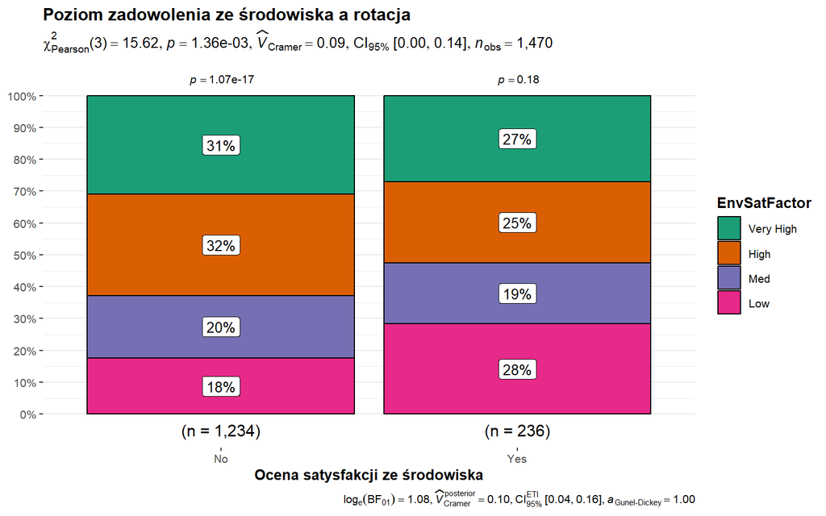

Interpretacja: Widoczny jest trend, w którym pracownicy oceniający środowisko jako “Niskie” (Low) odchodzą częściej niż ci z oceną “Bardzo wysoką” (Very High). Niska satysfakcja z biura/atmosfery sprzyja decyzjom o odejściu.

# 8 Odpowiedź na pytanie badawcze nr 2: Finanse a odejścia

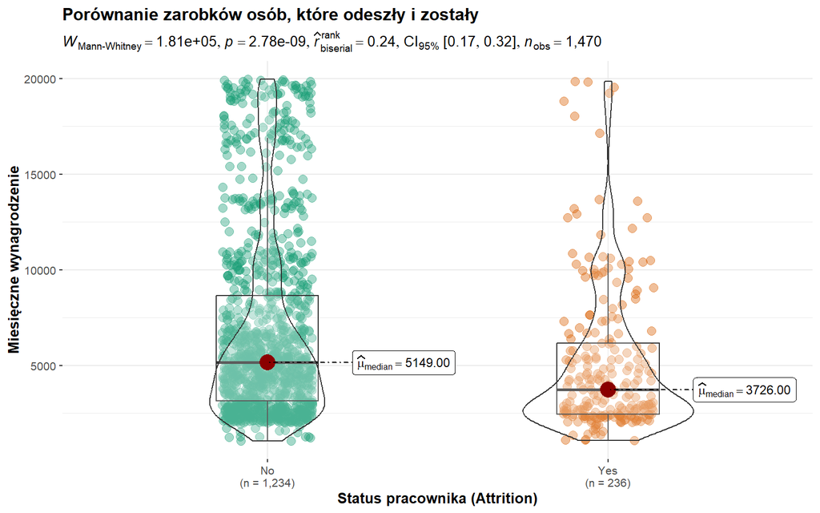

# 9 Odpowiedź na pytanie badawcze nr 3: Profil demograficzny (Wiek)

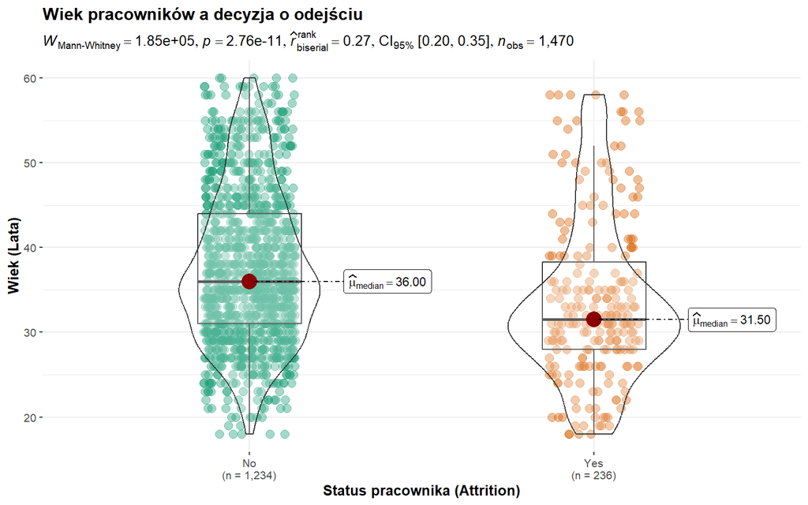

Interpretacja: Osoby decydujące się na odejście są statystycznie młodsze (mediana wieku ~32 lata) niż pracownicy lojalni (mediana ~36 lat). Firma ma największy problem z utrzymaniem młodych talentów.

# 10 Odpowiedź na pytanie badawcze nr 4: Analiza Działów (Departments)

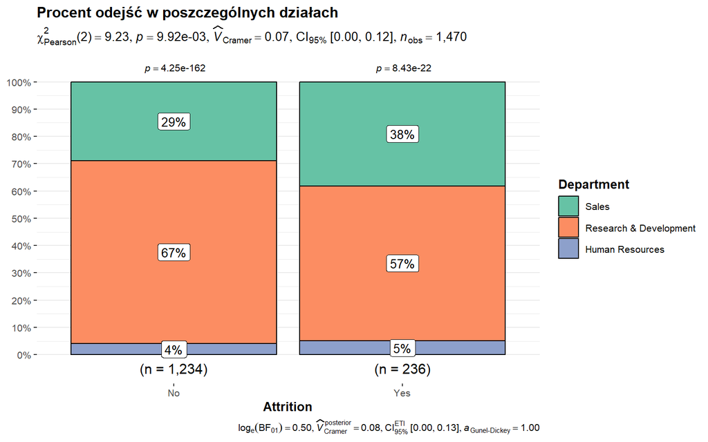

Interpretacja: Dział Sprzedaży (Sales) jest najbardziej narażony na rotację – odsetek odejść przekracza tu 20%. Dział Badawczo-Rozwojowy (R&D) cechuje się największą stabilnością kadry.

# 11 Wnioski końcowe

Celem niniejszej pracy było zidentyfikowanie kluczowych czynników finansowych oraz organizacyjnych wpływających na rotację pracowników – cel ten udało się osiągnąć. Przeprowadzona analiza statystyczna pozwoliła wyodrębnić główne determinanty odejść, którymi okazały się: poziom wynagrodzenia, obciążenie nadgodzinami oraz wiek pracownika.

## 11.1 Kluczowe wyniki

**Profil ryzyka:** Najczęściej odchodzą pracownicy młodzi oraz zatrudnieni w Dziale Sprzedaży.